# Analyse des Berichts der Kohlekommission

Dieses HTML-Dokument enthält Informationen über die Analyse des Abschlussberichts der Kommission „Wachstum, Strukturwandel und Beschäftigung“ (Stand 26. Januar 2018).

Als Erstes berechnen wir die Worthäufigkeiten:

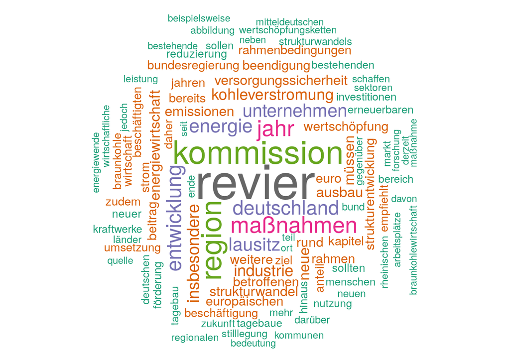

Auch als Histogramm:

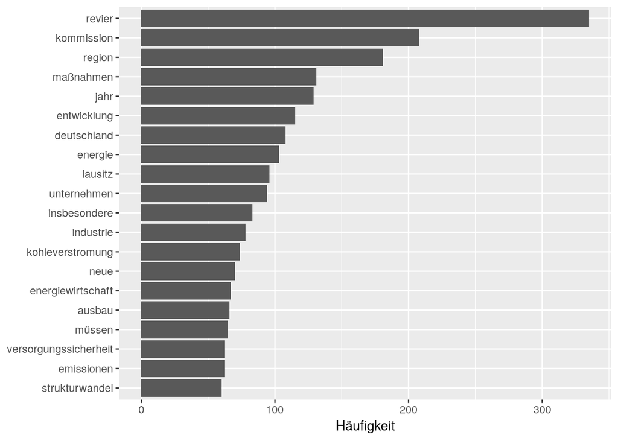

Wie ist die allgemeine Verteilung der Wortarten im Text:

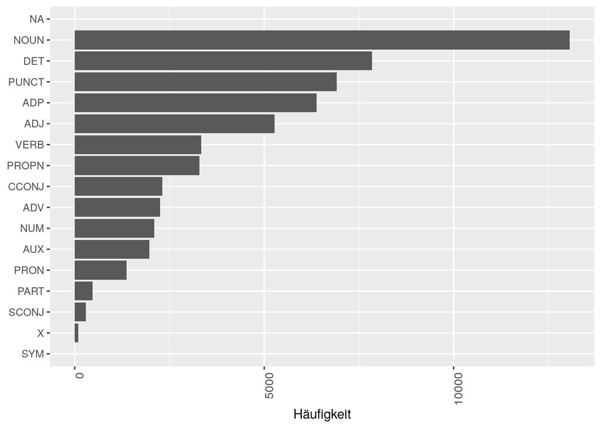

Die Häufigkeit von Wörter nach Wortart. Die Nomen sind sehr ähnlich zur Wortwolke weiter oben. Allerdings wurde ein anderes Paket benutzt, daher ist das Ergebniss leicht anders, jedoch in der Tendenz ähnlich.

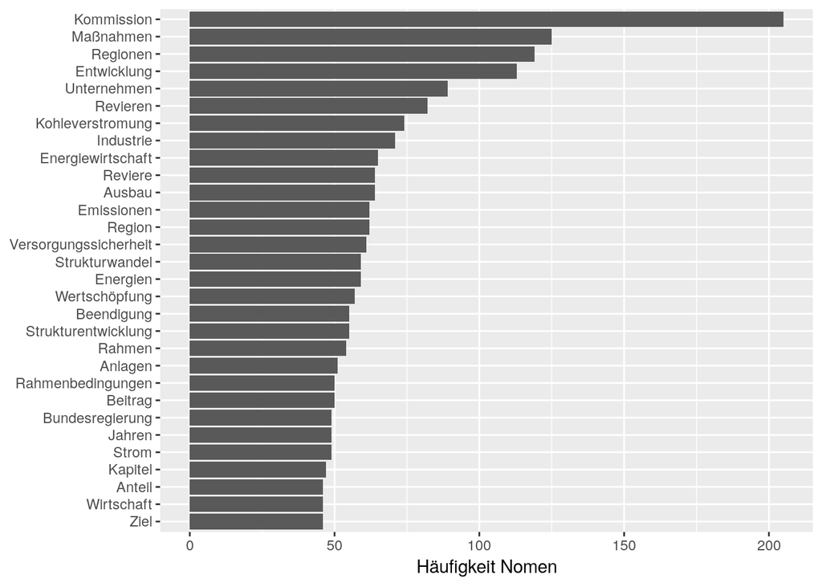

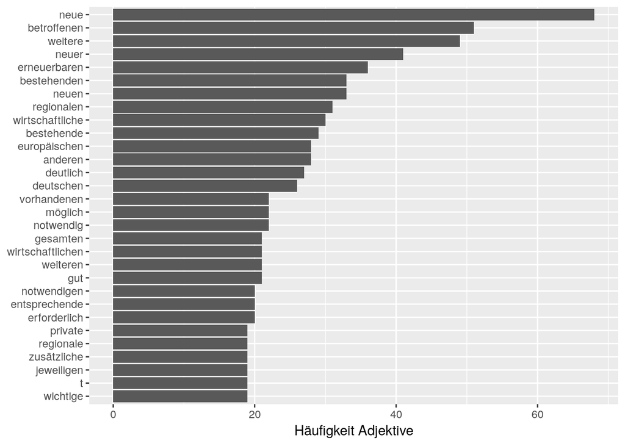

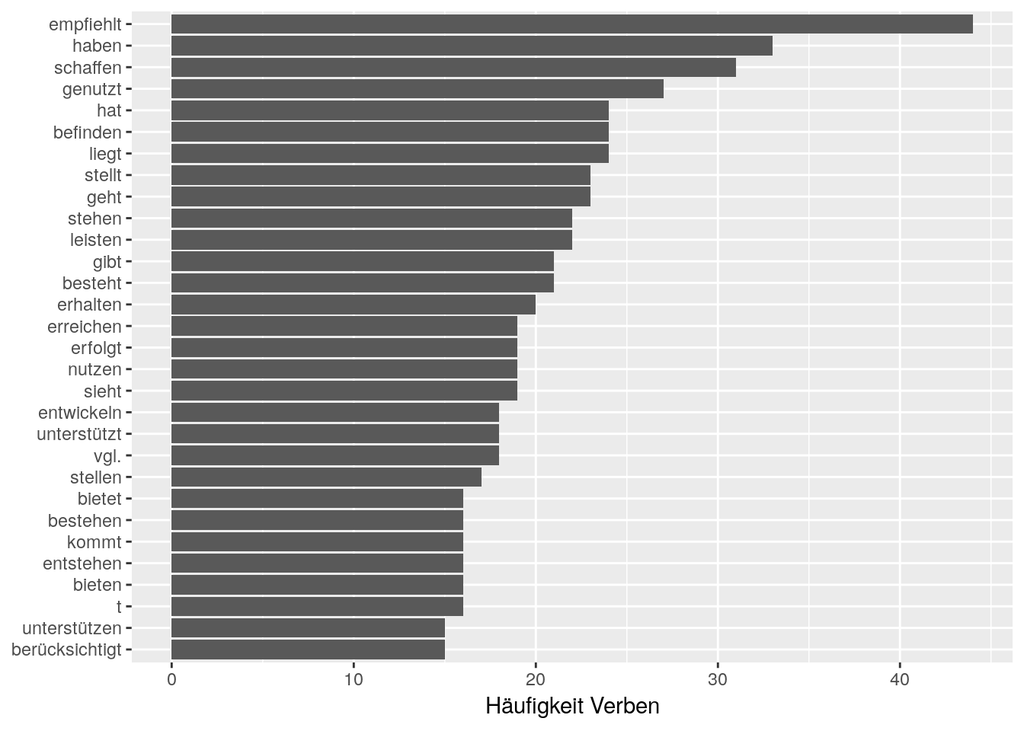

## Bigramme

Welche zwei Wörter werden am häufigsten hintereinander genannt?

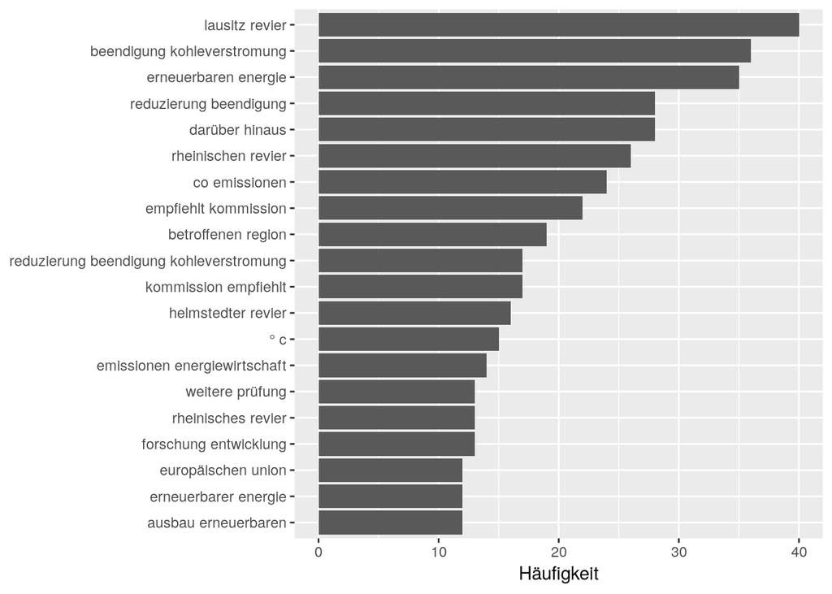

Es ist auch möglich die Keywords des Textes mittels des RAKE Algorithmus zu extrahieren

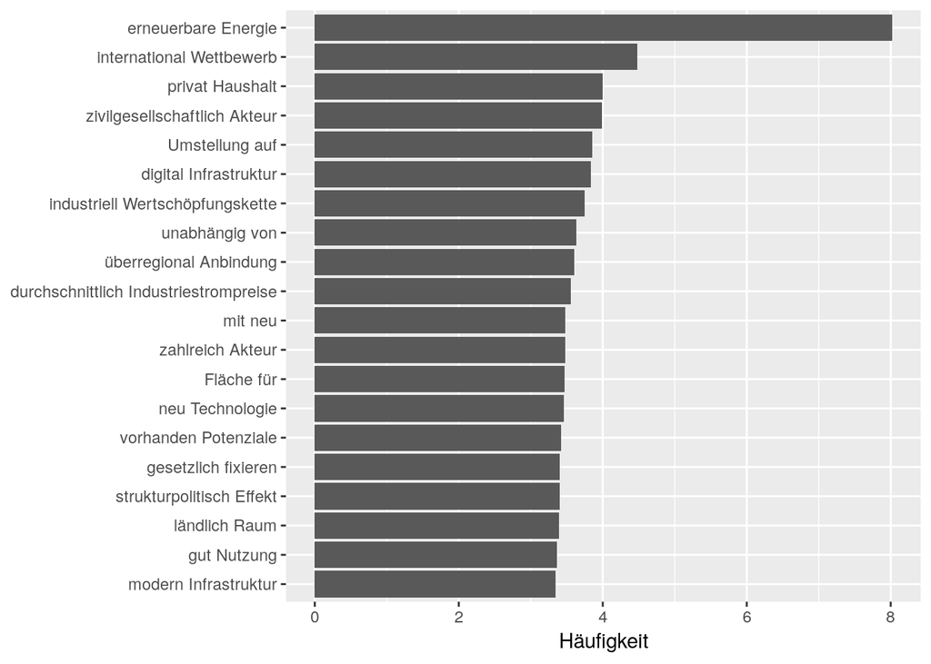

Ausgehend von den vorherigen Analysen lassen sich auch Graphen erstellen. Im Folgenden ist dargestellt, welche Adjektive und Nomen häufig zusammen in einem Satz vorkommen.

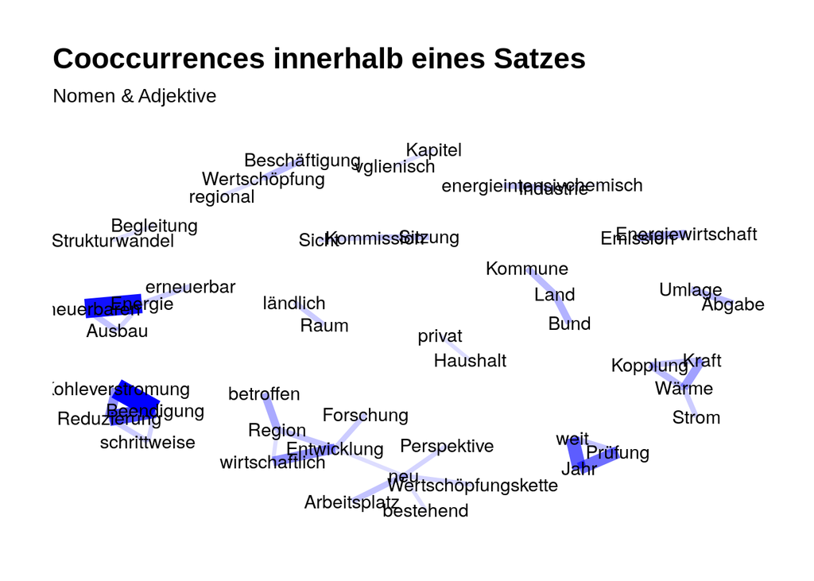

## Senitment Analysis

Eine Sentiment Analysis ermöglicht Emotionen in Texten zu erkennen. Welche Emotionen werden durch die Formulierungen im Bericht angesprochen?

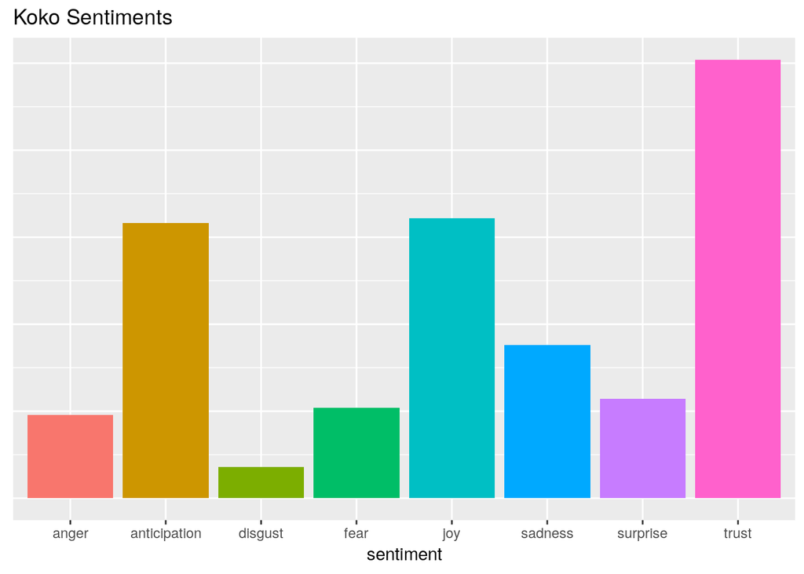

Wie ist die allgemeine Stimmung im Text?

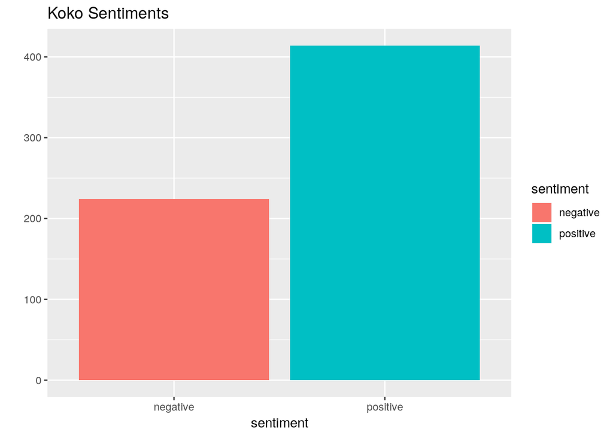

Wie entwickelt sich die Stimmung im Verlaufe des Textes? Dies ist insbesondere interessant, wenn die Analyse mit den entsprechenden Themen des Inhaltsverzeichnisses verglichen wird: S. 1-67 Ausgangslage (Klimapolitisch, Energiewirtschaftlich, Wachstum & Beschäftigung, Strukturpolitisch, Rechtliches), S. 70-80 Klimaschutz, S. 82-125 Perspektiven.

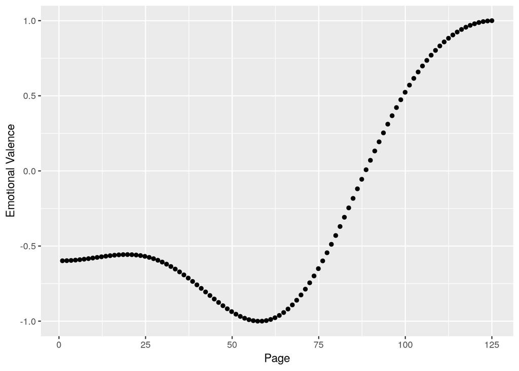